# LBB Regression

Ambiya Sang Aji

May 9, 2019

# Read Data dan merubah nama kolom agar lebih mudah untuk diinterpretasikan

```r
crime <- read.csv("crime.csv")
#remove column ID
crime$X <- NULL
#rename column
names(crime) <- c("percent_m", "is_south", "mean_education", "police_exp60", "police_exp59", "labour_participation", "m_per1000f", "state_pop", "nonwhites_per1000", "unemploy_m24", "unemploy_m39", "gdp", "inequality", "prob_prison", "time_prison", "crime_rate")
```

# Melakukan Analisis Data

Pertama-tama akan dilakukan pengecekan terhadap data yang akan dilakukan regresi terlebih dahulu

```r
str(crime)
```

```
## 'data.frame':    47 obs. of  16 variables:
##  $ percent_m           : int  151 143 142 136 141 121 127 131 157 140 ...
##  $ is_south            : int  1 0 1 0 0 0 1 1 1 0 ...
##  $ mean_education      : int  91 113 89 121 121 110 111 109 90 118 ...
##  $ police_exp60        : int  58 103 45 149 109 118 82 115 65 71 ...
##  $ police_exp59        : int  56 95 44 141 101 115 79 109 62 68 ...
##  $ labour_participation: int  510 583 533 577 591 547 519 542 553 632 ...
##  $ m_per1000f          : int  950 1012 969 994 985 964 982 969 955 1029 ...
##  $ state_pop           : int  33 13 18 157 18 25 4 50 39 7 ...
##  $ nonwhites_per1000   : int  301 102 219 80 30 44 139 179 286 15 ...
##  $ unemploy_m24        : int  108 96 94 102 91 84 97 79 81 100 ...
##  $ unemploy_m39        : int  41 36 33 39 20 29 38 35 28 24 ...
##  $ gdp                 : int  394 557 318 673 578 689 620 472 421 526 ...
##  $ inequality          : int  261 194 250 167 174 126 168 206 239 174 ...
##  $ prob_prison         : num  0.0846 0.0296 0.0834 0.0158 0.0414 ...
##  $ time_prison         : num  26.2 25.3 24.3 29.9 21.3 ...
##  $ crime_rate          : int  791 1635 578 1969 1234 682 963 1555 856 705 ...
```

Seluruh data memiliki tipe numerik, data dapat digunakan untuk kebutuhan regresi

Dikarenakan outut yang dihasilkan cukup panjang, tidak akan ditampilkan di report ini Setelah dilakukan pengecekan, data tidak memiliki missing value, tidak perlu dilakukan pre-prosesing lebih lanjut

# Melakukan pengecekan col dari seluruh predictor

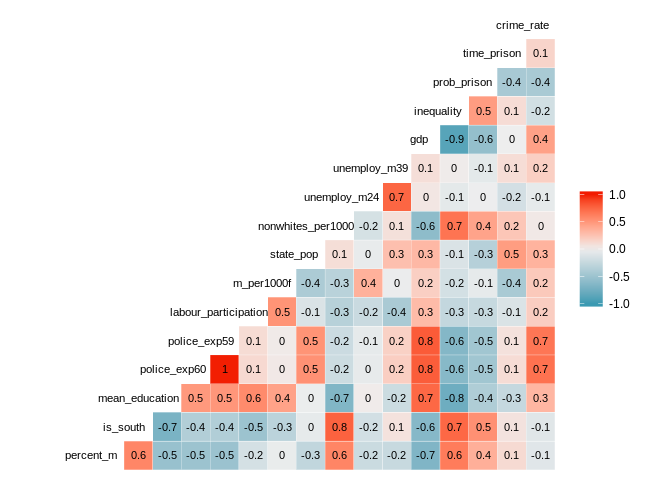

```r
ggcorr(crime, label = T,label_size = 2.9,  hjust = .85, size = 3,layout.exp=2)
```

Dari plot dapat terlihat variable police_exp59 dan police_exp60 saling mempengaruhi, karena hal ini, akan digunakan hanya 1 variabel saja, yaitu police_exp60 dalam predictor.

```r
#remove variable
crime$police_exp59 <- NULL
```

# Melakukan Feature Selection dengan Stepwise

Akan dilakukan feature Selection dengan menggunakan metode stepwise, membandingkan 3 arah (forward, backward, both)

```r
#Set up initial model
lm.0 <- lm(crime_rate ~1, crime)
lm.all <- lm(crime_rate ~., crime)
```

### Backward

```r
#Melakukan pemodelan dengan menggunakan backward selection
lm.bw <- step(lm.all, direction="backward")
```

```
## Start:  AIC=513.95
## crime_rate ~ percent_m + is_south + mean_education + police_exp60 +
##     labour_participation + m_per1000f + state_pop + nonwhites_per1000 +
##     unemploy_m24 + unemploy_m39 + gdp + inequality + prob_prison +
##     time_prison
##
##                        Df Sum of Sq     RSS    AIC
## - is_south              1        64 1392929 511.95
## - time_prison           1      1236 1394101 511.99
## - labour_participation  1      1723 1394588 512.00
## - nonwhites_per1000     1      6802 1399667 512.18
## - state_pop             1     16168 1409033 512.49
## - gdp                   1     33582 1426447 513.07
## - m_per1000f            1     35080 1427945 513.12
## <none>                              1392865 513.95
## - unemploy_m24          1     73136 1466001 514.35
## - prob_prison           1    167590 1560455 517.29
## - unemploy_m39          1    185009 1577874 517.81
## - percent_m             1    203389 1596254 518.35
## - mean_education        1    369864 1762729 523.01
## - inequality            1    451937 1844802 525.15
## - police_exp60          1    708738 2101603 531.28
##
## Step:  AIC=511.95
## crime_rate ~ percent_m + mean_education + police_exp60 + labour_participation +
##     m_per1000f + state_pop + nonwhites_per1000 + unemploy_m24 +
##     unemploy_m39 + gdp + inequality + prob_prison + time_prison
##
##                        Df Sum of Sq     RSS    AIC
## - time_prison           1      1319 1394247 509.99
## - labour_participation  1      2646 1395574 510.04
## - nonwhites_per1000     1      8949 1401878 510.25
## - state_pop             1     16166 1409095 510.49
## - gdp                   1     36125 1429054 511.15
## - m_per1000f            1     36467 1429396 511.16
## <none>                              1392929 511.95
## - unemploy_m24          1     86999 1479928 512.80
## - prob_prison           1    171381 1564310 515.40
## - unemploy_m39          1    196372 1589301 516.15
## - percent_m             1    206121 1599050 516.43
```

[output cut: 76 more lines]

```
##
## Step:  AIC=503.93
## crime_rate ~ percent_m + mean_education + police_exp60 + m_per1000f +
##     unemploy_m24 + unemploy_m39 + inequality + prob_prison
##
##                  Df Sum of Sq     RSS    AIC
## <none>                        1453068 503.93
## - m_per1000f      1    103159 1556227 505.16
## - unemploy_m24    1    127044 1580112 505.87
## - prob_prison     1    247978 1701046 509.34
## - unemploy_m39    1    255443 1708511 509.55
## - percent_m       1    296790 1749858 510.67
## - mean_education  1    445788 1898855 514.51
## - inequality      1    738244 2191312 521.24
## - police_exp60    1   1672038 3125105 537.93
```

### Both

```r
#Melakukan pemodelan dengan menggunakan both(forward and backward) selection
lm.bt <- step(lm.0, scope=list(upper=lm.all),direction="both")
```

```
## Start:  AIC=561.02
## crime_rate ~ 1
##
##                        Df Sum of Sq     RSS    AIC
## + police_exp60          1   3253302 3627626 532.94
## + gdp                   1   1340152 5540775 552.84
## + prob_prison           1   1257075 5623853 553.54
## + state_pop             1    783660 6097267 557.34
## + mean_education        1    717146 6163781 557.85
## + m_per1000f            1    314867 6566061 560.82
## <none>                              6880928 561.02
## + labour_participation  1    245446 6635482 561.32
## + inequality            1    220530 6660397 561.49
## + unemploy_m39          1    216354 6664573 561.52
## + time_prison           1    154545 6726383 561.96
## + is_south              1     56527 6824400 562.64
## + percent_m             1     55084 6825844 562.65
## + unemploy_m24          1     17533 6863395 562.90
## + nonwhites_per1000     1      7312 6873615 562.97
##
## Step:  AIC=532.94
## crime_rate ~ police_exp60
##
##                        Df Sum of Sq     RSS    AIC
## + inequality            1    739819 2887807 524.22
## + percent_m             1    616741 3010885 526.18
## + m_per1000f            1    250522 3377104 531.57
## + nonwhites_per1000     1    232434 3395192 531.82
## + is_south              1    219098 3408528 532.01
## + gdp                   1    180872 3446754 532.53
## <none>                              3627626 532.94
## + prob_prison           1     92278 3535348 533.72
## + labour_participation  1     77479 3550147 533.92
## + time_prison           1     43185 3584441 534.37
## + unemploy_m39          1     17848 3609778 534.70
## + state_pop             1      5666 3621959 534.86
## + unemploy_m24          1      2878 3624748 534.90
## + mean_education        1       767 3626859 534.93
## - police_exp60          1   3253302 6880928 561.02
##
```

[output cut: 86 more lines]

```
## <none>                              1611057 504.79
## + gdp                   1     59910 1551147 505.00
## + unemploy_m24          1     54830 1556227 505.16
## + state_pop             1     51320 1559737 505.26
## + m_per1000f            1     30945 1580112 505.87
## + is_south              1     17958 1593098 506.26
## + labour_participation  1     13179 1597878 506.40
## + time_prison           1      7159 1603898 506.58
## + nonwhites_per1000     1       359 1610698 506.78
## - unemploy_m39          1    192233 1803290 508.08
## - prob_prison           1    249308 1860365 509.55
## - percent_m             1    400611 2011667 513.22
## - mean_education        1    776207 2387264 521.27
## - inequality            1    949221 2560278 524.56
## - police_exp60          1   2817067 4428124 550.31
```

### Forward

```r
#Melakukan pemodelan dengan menggunakan forkward selection
lm.fw <- step(lm.0, scope=list(lower=lm.0, upper=lm.all),direction="forward")
```

```
## Start:  AIC=561.02
## crime_rate ~ 1
##
##                        Df Sum of Sq     RSS    AIC
## + police_exp60          1   3253302 3627626 532.94
## + gdp                   1   1340152 5540775 552.84
## + prob_prison           1   1257075 5623853 553.54
## + state_pop             1    783660 6097267 557.34
## + mean_education        1    717146 6163781 557.85
## + m_per1000f            1    314867 6566061 560.82
## <none>                              6880928 561.02
## + labour_participation  1    245446 6635482 561.32
## + inequality            1    220530 6660397 561.49
## + unemploy_m39          1    216354 6664573 561.52
## + time_prison           1    154545 6726383 561.96
## + is_south              1     56527 6824400 562.64
## + percent_m             1     55084 6825844 562.65
## + unemploy_m24          1     17533 6863395 562.90
## + nonwhites_per1000     1      7312 6873615 562.97
##
## Step:  AIC=532.94
## crime_rate ~ police_exp60
##
##                        Df Sum of Sq     RSS    AIC
## + inequality            1    739819 2887807 524.22
## + percent_m             1    616741 3010885 526.18
## + m_per1000f            1    250522 3377104 531.57
## + nonwhites_per1000     1    232434 3395192 531.82
## + is_south              1    219098 3408528 532.01
## + gdp                   1    180872 3446754 532.53
## <none>                              3627626 532.94
## + prob_prison           1     92278 3535348 533.72
## + labour_participation  1     77479 3550147 533.92
## + time_prison           1     43185 3584441 534.37
## + unemploy_m39          1     17848 3609778 534.70
## + state_pop             1      5666 3621959 534.86
## + unemploy_m24          1      2878 3624748 534.90
## + mean_education        1       767 3626859 534.93
##
## Step:  AIC=524.22
```

[output cut: 65 more lines]

```
##
## Step:  AIC=504.79
## crime_rate ~ police_exp60 + inequality + mean_education + percent_m +
##     prob_prison + unemploy_m39
##
##                        Df Sum of Sq     RSS    AIC
## <none>                              1611057 504.79
## + gdp                   1     59910 1551147 505.00
## + unemploy_m24          1     54830 1556227 505.16
## + state_pop             1     51320 1559737 505.26
## + m_per1000f            1     30945 1580112 505.87
## + is_south              1     17958 1593098 506.26
## + labour_participation  1     13179 1597878 506.40
## + time_prison           1      7159 1603898 506.58
## + nonwhites_per1000     1       359 1610698 506.78
```

### Summary Forward

```r
summary(lm.fw)
```

```
##
## Call:
## lm(formula = crime_rate ~ police_exp60 + inequality + mean_education +
##     percent_m + prob_prison + unemploy_m39, data = crime)
##
## Residuals:
##     Min      1Q  Median      3Q     Max
## -470.68  -78.41  -19.68  133.12  556.23
##
## Coefficients:
##                 Estimate Std. Error t value Pr(>|t|)
## (Intercept)    -5040.505    899.843  -5.602 1.72e-06 ***
## police_exp60      11.502      1.375   8.363 2.56e-10 ***
## inequality         6.765      1.394   4.855 1.88e-05 ***
## mean_education    19.647      4.475   4.390 8.07e-05 ***
## percent_m         10.502      3.330   3.154  0.00305 **
## prob_prison    -3801.836   1528.097  -2.488  0.01711 *
## unemploy_m39       8.937      4.091   2.185  0.03483 *
## ---
## Signif. codes:  0 '***' 0.001 '**' 0.01 '*' 0.05 '.' 0.1 ' ' 1
##
## Residual standard error: 200.7 on 40 degrees of freedom
## Multiple R-squared:  0.7659, Adjusted R-squared:  0.7307
## F-statistic: 21.81 on 6 and 40 DF,  p-value: 3.418e-11
```

### Summary Both

```r
summary(lm.bt)
```

```
##
## Call:
## lm(formula = crime_rate ~ police_exp60 + inequality + mean_education +
##     percent_m + prob_prison + unemploy_m39, data = crime)
##
## Residuals:
##     Min      1Q  Median      3Q     Max
## -470.68  -78.41  -19.68  133.12  556.23
##
## Coefficients:
##                 Estimate Std. Error t value Pr(>|t|)
## (Intercept)    -5040.505    899.843  -5.602 1.72e-06 ***
## police_exp60      11.502      1.375   8.363 2.56e-10 ***
## inequality         6.765      1.394   4.855 1.88e-05 ***
## mean_education    19.647      4.475   4.390 8.07e-05 ***
## percent_m         10.502      3.330   3.154  0.00305 **
## prob_prison    -3801.836   1528.097  -2.488  0.01711 *
## unemploy_m39       8.937      4.091   2.185  0.03483 *
## ---
## Signif. codes:  0 '***' 0.001 '**' 0.01 '*' 0.05 '.' 0.1 ' ' 1
##
## Residual standard error: 200.7 on 40 degrees of freedom
## Multiple R-squared:  0.7659, Adjusted R-squared:  0.7307
## F-statistic: 21.81 on 6 and 40 DF,  p-value: 3.418e-11
```

### Summary Backward

```r
summary(lm.bw)
```

```
##
## Call:
## lm(formula = crime_rate ~ percent_m + mean_education + police_exp60 +
##     m_per1000f + unemploy_m24 + unemploy_m39 + inequality + prob_prison,
##     data = crime)
##
## Residuals:
##     Min      1Q  Median      3Q     Max
## -444.70 -111.07    3.03  122.15  483.30
##
## Coefficients:
##                 Estimate Std. Error t value Pr(>|t|)
## (Intercept)    -6426.101   1194.611  -5.379 4.04e-06 ***
## percent_m          9.332      3.350   2.786  0.00828 **
## mean_education    18.012      5.275   3.414  0.00153 **
## police_exp60      10.265      1.552   6.613 8.26e-08 ***
## m_per1000f         2.234      1.360   1.642  0.10874
## unemploy_m24      -6.087      3.339  -1.823  0.07622 .
## unemploy_m39      18.735      7.248   2.585  0.01371 *
## inequality         6.133      1.396   4.394 8.63e-05 ***
## prob_prison    -3796.032   1490.646  -2.547  0.01505 *
## ---
## Signif. codes:  0 '***' 0.001 '**' 0.01 '*' 0.05 '.' 0.1 ' ' 1
##
## Residual standard error: 195.5 on 38 degrees of freedom
## Multiple R-squared:  0.7888, Adjusted R-squared:  0.7444
## F-statistic: 17.74 on 8 and 38 DF,  p-value: 1.159e-10
```

Dari hasil summary 3 model diatas, jika dailihat dari Adj R-squarenya, model yang terbaik adalah model yang menggunakan 8 predictor, yaitu percent_m + mean_education + police_exp60 + m_per1000f + unemploy_m24 + unemploy_m39 + inequality + prob_prison, yang didapatkan dari metode stepwise backward. Selanjutnya akan dicek distribusi dari residual untuk dilihat apakah residual menyebar secara distribusi normal.

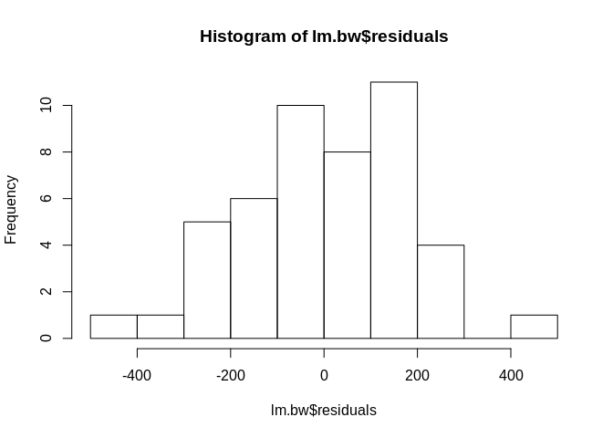

```r
hist(lm.bw$residuals, breaks = 10)
```

```r
shapiro.test(lm.bw$residuals)
```

```
##
##  Shapiro-Wilk normality test
##
## data:  lm.bw$residuals
## W = 0.98511, p-value = 0.8051
```

Berdasarkan histogram diatas, dapat dilihat residual menyebar secara normal, hal ini dapat dicek juga di dalam hasil saphiro test, dimana nilai p-valuenya 0.8 atau dapat dikatakan sangat besar, dimana hal ini menandakan residual menyebar secara distribusi normal

Selanjutnya akan dilakukan pengecekan kondisi colinearity dari model saat ini, dengan plot heatmap yang sama dengan yang dilakukan pada awal pembentukan model

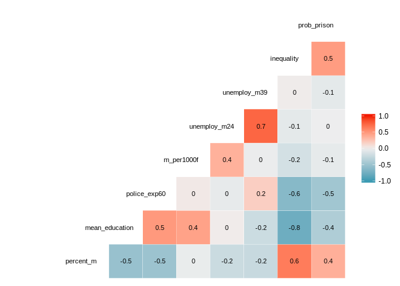

```r
crimemodel <- crime[,c("percent_m","mean_education","police_exp60","m_per1000f","unemploy_m24","unemploy_m39","inequality","prob_prison")]
ggcorr(crimemodel, label = T,label_size = 2.9,hjust = .85, size = 3,layout.exp=2)
```

Dari plot diatas, dapat dilihat tidak ada predictor yang sangat mempengaruhi sesamaa predictor lain nya, akan dilakukan juga pengecekan hal ini menggunakan metode vif

```r
vif(lm.bw)
```

```
##      percent_m mean_education   police_exp60     m_per1000f   unemploy_m24
##       2.131963       4.189684       2.560496       1.932367       4.360038
##   unemploy_m39     inequality    prob_prison
##       4.508106       3.731074       1.381879
```

Dari hasil test diatas, dapat dilihat tidak ada predictor yang memiliki nilai vif 10, yang berarti tidak ada predictor yang mempengaruhi predictor lain nya

Selanjutnya akan dilakukan pengecekan heteroskedasticity (melakukan pengecekan pola residual)

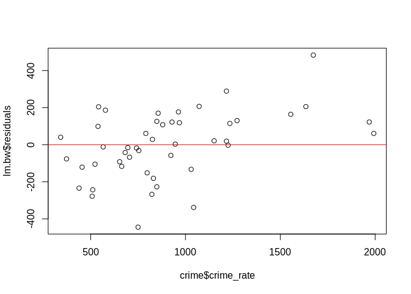

```r
plot(crime$crime_rate, lm.bw$residuals)
abline(h = 0, col="red")
```

```r
bptest(lm.bw)
```

```
##
##  studentized Breusch-Pagan test
##
## data:  lm.bw
## BP = 13.51, df = 8, p-value = 0.09546
```

Dari plot diatas, dapat terlihat residual menyebar secara acak atau tidak memiliki pola, dapat dilihat juga di dalam Breusch-Pagan test yang dilakukan, p value menunjukkan angka diatas 0.05, hal ini berarti model sudah menangkap pola yang ada di dalam data dengan baik

Akan dilakukan pengecekan menghilangkan variable yang memiliki nilai vif diatas 4, dimulai dari yang tertinggi yaitu yaitu unemploy_m39

```r
#remove unemploy_m39
lm2 <- lm(crime_rate~percent_m+mean_education+police_exp60+m_per1000f+unemploy_m24+inequality+prob_prison,crime)
vif(lm2)
```

```
##      percent_m mean_education   police_exp60     m_per1000f   unemploy_m24
##       2.076024       3.701947       1.869695       1.821401       1.428365
##     inequality    prob_prison
##       3.670985       1.380068
```

Setelah dilakukan pengecekan vif kembali, tidak ada nilai vif diatas 4 saat ini, maka selanjutnya akan di cek summary dari model yang dibentuk di atas

```r
#pngecekan summary dari model baru
summary(lm2)
```

```
##
## Call:
## lm(formula = crime_rate ~ percent_m + mean_education + police_exp60 +
##     m_per1000f + unemploy_m24 + inequality + prob_prison, data = crime)
##
## Residuals:
##     Min      1Q  Median      3Q     Max
## -488.85  -96.86   -6.07  132.54  527.04
##
## Coefficients:
##                  Estimate Std. Error t value Pr(>|t|)
## (Intercept)    -5210.6908  1175.4173  -4.433 7.35e-05 ***
## percent_m          7.9297     3.5380   2.241   0.0308 *
## mean_education    13.3599     5.3076   2.517   0.0161 *
## police_exp60      12.3494     1.4199   8.698 1.14e-10 ***
## m_per1000f         1.3916     1.4134   0.985   0.3309
## unemploy_m24       0.9905     2.0457   0.484   0.6310
## inequality         6.5914     1.4820   4.447 7.03e-05 ***
## prob_prison    -3935.5261  1594.4658  -2.468   0.0181 *
## ---
## Signif. codes:  0 '***' 0.001 '**' 0.01 '*' 0.05 '.' 0.1 ' ' 1
##
## Residual standard error: 209.3 on 39 degrees of freedom
## Multiple R-squared:  0.7517, Adjusted R-squared:  0.7071
## F-statistic: 16.87 on 7 and 39 DF,  p-value: 5.08e-10
```

Dari percobaan diatas, dalam kasus ini, menghilangkan nilai dengan vif tinggi > 4 ternyata akan mengurangi nilai r square dari model, dengan kata lain kualitas model menjadi lebih buruk. Selanjutnya akan dilakukan pengecekan seluruh kombinasi variable yang ada, yang mana yang akan menghasilkan nilai R square terbesar

# Melakukan pengecekan all possible R square dengan menggunakan package leaps

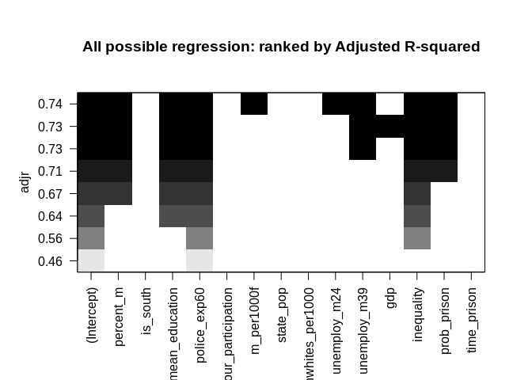

```r
crm <- regsubsets(crime_rate ~ percent_m+is_south+mean_education+police_exp60+labour_participation+m_per1000f+state_pop+nonwhites_per1000+unemploy_m24+unemploy_m39+gdp+inequality+prob_prison+time_prison, crime, nbest=1)
plot(crm, scale="adjr", main="All possible regression: ranked by Adjusted R-squared")
```

Dari plot diatas, dapat dilihat nilai R square terbaik dihasilkan oleh variabel yang sama dengan yang dihasilkan menggunakan metode stepwise backward selection

# Additional Test, pelakukan pengecekan prediksi ke data baru

Read data dan melakukan prediksi terhadap data menggunakan model yang telah dibentuk

```r
crimex <- read.csv("new_crime.csv")
prd <- predict(lm.bw, crimex)
```

Akan dilakukan pengecekan besarnya error dari model

```r
cat("Error Model :", sqrt(mean((crimex$crime_rate - prd)^2)),"\n")
```

```
## Error Model : 163.0906
```

```r
cat("Range Y Train Data :", range(crime$crime_rate), "\n")
```

```
## Range Y Train Data : 342 1993
```

```r
cat("Range Y Test Data :", range(crimex$crime_rate), "\n")
```

```
## Range Y Test Data : 508 1969
```

Dapat dilihat dari pengecekan error dengan metode RMSE, error yang dihasilkan memiliki nilai 163, jika dilihat dari range data, error yang dihasilkan dapat dibilang tergolong cukup tinggi.

# Additional Test, Regresi dengan menggunakan Gradient Descend Algorithm

Pertama, melakukan Inisialisasi Data dan Preprocessing data untuk pemodelan

```r
#Inisialisasi Data (Menggunakan variabel yang sama dengan model sebelumnya), Memisahkan X (Predictor) dab Y(Target)
X <- crime[,c("percent_m","mean_education","police_exp60","m_per1000f","unemploy_m24","unemploy_m39","inequality","prob_prison")]
y <- crime$crime_rate
Prepx <- function(X){
#Normalisasi data menggunakan z-score
for (p in seq(1, ncol(X), by=1)) {
X[,p] <- (X[,p] - mean(X[,p])) / sd(X[,p])
}
#Inisialisasi data untuk intercept
X$ones <- 1
#ubah X sebagai matrix
X <- as.matrix(X)
return(X)
}
Prepy <- function(y){
#Normalisasi data menggunakan z-score
y <- (y-mean(y))/sd(y)
return(y)
}
X <- Prepx(X)
y <- Prepy(y)
#Pengecekan Range untuk kebutuhan Denormalisasi
range(crime$crime_rate)
```

```
## [1]  342 1993
```

Range dari target y adalah 342 - 1993, ini akan digunakan nantinya untuk komparasi denormalisasi data.

Selanjutnya akan melakukan inisialisasi variabel dari fungsi

```r
#Inisialisasi variabel untuk fungsi
m <- as.numeric(nrow(X))
n <- as.numeric(ncol(X))
alpha <- 0.01
num_iter <- 50000
J_history <<- matrix(0, num_iter+1, 1)
theta <- as.vector(matrix(0, n, 1))
J_history[1,1] <- 1
```

Membuat fungsi algoritma Gradient Descend

```r
#Gradient Descend
GD <- function(X,y,alpha,num_iter,m,n) {
  for (i in seq(1, num_iter, by=1)){
    thetabckp <- theta
    theta <- theta - ((alpha*(1/m))*as.vector(colSums(as.vector(rowSums(t(as.vector(theta)*t(X))) - y)*X)))
    J_history[i+1,1] <- computeCostMulti(X,y,theta,m)
    if ((J_history[i+1,1]-J_history[i,1]) > 0){
      theta <- thetabckp
      break
    }
  }
return(theta)
}

computeCostMulti <- function(X,y,theta,m){
  J <- 0
  J <<- (1/(2*m)) * sum((((rowSums(t(as.vector(theta)*t(X))) - y))^2))
}
thetaPred <- GD(X,y,alpha,num_iter,m,n)
```

Melakukan prediksi, dan pengecekan terhadap hasil prediksi

```r
#Melakukan Prediksi Terhadap Data
ypred<-rowSums(t((thetaPred*t(X))))
cat("Error Model :", sqrt(mean((y - ypred)^2)), "\n")
```

```
## Error Model : 0.4546209
```

```r
cat("Range Actual Y :", range(y) , "\n")
```

```
## Range Actual Y : -1.455893 2.812874
```

```r
cat("Range Y Predict :", range(ypred) , "\n")
```

```
## Range Y Predict : -1.559593 2.655632
```

```r
cat("Adj. R Square Model :", 1-(1- sum((ypred - mean(y))^2)/sum((y - mean(y))^2))*(m-1)/(m-(n-1)-1) , "\n")
```

```
## Adj. R Square Model : 0.7443692
```

Melakukan Denormalisasi data, dan melakukan pengecekan terhadap hasil prediksi setelah di denormaslisasi

```r
#Denormalize Data
y <- y*sd(crime$crime_rate)+mean(crime$crime_rate)
ypred <- ypred*sd(crime$crime_rate)+mean(crime$crime_rate)
cat("Range Actual Y :", range(y) , "\n")
```

```
## Range Actual Y : 342 1993
```

```r
cat("Range Actual Y :", range(ypred) , "\n")
```

```
## Range Actual Y : 301.8928 1932.185
```

```r
cat("Error Model :", sqrt(mean((y - ypred)^2)), "\n")
```

```
## Error Model : 175.8304
```

Denomalisasi berhasil, range data sama sepert yang sebelumnya

Dengan menggunakan algoritma gradient descend, dengan variabel yang sama dengan model sebelumnya, didapatkan nilai Adj R squarenya di angka 0.74, nilai yang tidak jauh berbeda dengan nilai Adj R Square di model sebelumnya. nilai error berkisar di angka 175, dapat dikatakan itu adalah nilai yang cukup besar, jika dilihat dari range data yang berkisar di angka 342 - 1993

selanjutnya akan dilakukan pengecekan multicol, heteroskedasticity, dan normality dari data

## Heteroskedasticity

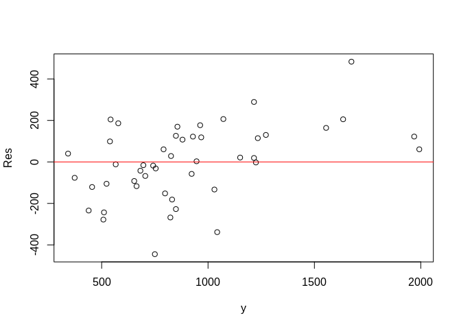

```r
Res <- y-ypred
plot(y, Res)
abline(h = 0, col="red")
```

## Normality

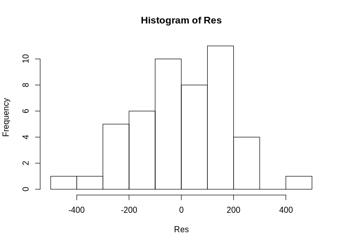

```r
hist(Res, breaks = 10)
```

```r
shapiro.test(lm.bw$residuals)
```

```
##
##  Shapiro-Wilk normality test
##
## data:  lm.bw$residuals
## W = 0.98511, p-value = 0.8051
```

## Multicolinearity

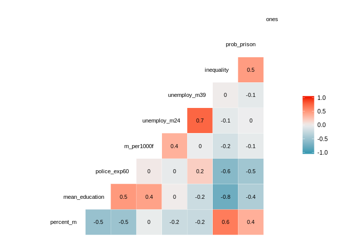

```r
ggcorr(X, label = T,label_size = 2.9, hjust = .85, size = 3,layout.exp=2)
```

Melakukan pengecekan VIF dari masing masing variabel prediktor

```r
vif <- data.frame(matrix(0, 8, 2))
colnames(vif) <- c("Var","VIF")
X <- crime[,c("percent_m","mean_education","police_exp60","m_per1000f","unemploy_m24","unemploy_m39","inequality","prob_prison")]
y <- crime$crime_rate
X <- Prepx(X)
y <- Prepy(y)
thetaPred <- GD(X,y,alpha,num_iter,m,n)
ypred<-rowSums(t((thetaPred*t(X))))
vif[1,1]<-"crime rate"
vif[1,2]<- 1/(1-(sum((ypred - mean(y))^2)/sum((y - mean(y))^2)))
X <- crime[,c("crime_rate","mean_education","police_exp60","m_per1000f","unemploy_m24","unemploy_m39","inequality","prob_prison")]
y <- crime$percent_m
X <- Prepx(X)
y <- Prepy(y)
thetaPred <- GD(X,y,alpha,num_iter,m,n)
ypred<-rowSums(t((thetaPred*t(X))))
vif[2,1]<-"percent_m"
vif[2,2]<- 1/(1-(sum((ypred - mean(y))^2)/sum((y - mean(y))^2)))
X <- crime[,c("crime_rate","percent_m","police_exp60","m_per1000f","unemploy_m24","unemploy_m39","inequality","prob_prison")]
y <- crime$mean_education
X <- Prepx(X)
y <- Prepy(y)
thetaPred <- GD(X,y,alpha,num_iter,m,n)
ypred<-rowSums(t((thetaPred*t(X))))
vif[3,1]<-"mean_education"
vif[3,2]<- 1/(1-(sum((ypred - mean(y))^2)/sum((y - mean(y))^2)))
X <- crime[,c("crime_rate","percent_m","mean_education","m_per1000f","unemploy_m24","unemploy_m39","inequality","prob_prison")]
y <- crime$police_exp60
X <- Prepx(X)
y <- Prepy(y)
thetaPred <- GD(X,y,alpha,num_iter,m,n)
ypred<-rowSums(t((thetaPred*t(X))))
vif[4,1]<-"police_exp60"
vif[4,2]<- 1/(1-(sum((ypred - mean(y))^2)/sum((y - mean(y))^2)))
X <- crime[,c("crime_rate","percent_m","mean_education","m_per1000f","police_exp60","unemploy_m39","inequality","prob_prison")]
y <- crime$unemploy_m24
X <- Prepx(X)
y <- Prepy(y)
thetaPred <- GD(X,y,alpha,num_iter,m,n)
ypred<-rowSums(t((thetaPred*t(X))))
vif[5,1]<-"unemploy_m24"
vif[5,2]<- 1/(1-(sum((ypred - mean(y))^2)/sum((y - mean(y))^2)))
X <- crime[,c("crime_rate","percent_m","mean_education","m_per1000f","police_exp60","unemploy_m24","inequality","prob_prison")]
y <- crime$unemploy_m39
X <- Prepx(X)
y <- Prepy(y)
thetaPred <- GD(X,y,alpha,num_iter,m,n)
ypred<-rowSums(t((thetaPred*t(X))))
vif[6,1]<-"unemploy_m39"
vif[6,2]<- 1/(1-(sum((ypred - mean(y))^2)/sum((y - mean(y))^2)))
X <- crime[,c("crime_rate","percent_m","mean_education","m_per1000f","police_exp60","unemploy_m24","unemploy_m39","prob_prison")]
y <- crime$inequality
X <- Prepx(X)
y <- Prepy(y)
thetaPred <- GD(X,y,alpha,num_iter,m,n)
ypred<-rowSums(t((thetaPred*t(X))))
vif[7,1]<-"inequality"
vif[7,2]<- 1/(1-(sum((ypred - mean(y))^2)/sum((y - mean(y))^2)))
X <- crime[,c("crime_rate","percent_m","mean_education","m_per1000f","police_exp60","unemploy_m24","unemploy_m39","inequality")]
y <- crime$prob_prison
X <- Prepx(X)
y <- Prepy(y)
thetaPred <- GD(X,y,alpha,num_iter,m,n)
ypred<-rowSums(t((thetaPred*t(X))))
vif[8,1]<-"prob_prison"
vif[8,2]<- 1/(1-(sum((ypred - mean(y))^2)/sum((y - mean(y))^2)))
vif
```

```
##              Var      VIF
## 1     crime rate 4.735448
## 2      percent_m 2.567418
## 3 mean_education 5.475040
## 4   police_exp60 5.506844
## 5   unemploy_m24 4.741243
## 6   unemploy_m39 5.300611
## 7     inequality 5.626679
## 8    prob_prison 1.617708
```

Dari test diatas, dapat dikatakan model sudah membentuk data dengan baik, tidak ada nilai vif > 10, residual menyebar secara distribusi normal dan residual tidak memiliki pola